# Sample size estimation for an effect size of interest in GLMM

Pratik Bhandari

2022-02-03 (last revised: 2022-02-04 16:12:21)

# 1 Setup

```r
set.seed(2022)

suppressPackageStartupMessages(library(tidyr))
suppressPackageStartupMessages(library(dplyr))
suppressPackageStartupMessages(library(simr))
```

# 2 Createa a fake data

Let’s say we have already run a pilot experiment so that we can conduct a well-powered experiment for a study that we can publish and/or write in our thesis.

- Within group design, with n=26
- 2 condition:
  - Noise: Mild and Severe
  - Cloze: High and Low
- 10 items in a repeated measures design

In this hypothetical experiment with 26 participants, each participant listens to 40 sentences. These sentences are embedded in background noise which is Mild or Severe. The [cloze probability](https://doi.org/10.1177/107769905303000401) of the sentence final words are High or Low.

```r
dat <- expand_grid(
  participants = paste(letters, 1:26, sep = '_'),
  noise = c('mild', 'severe'),
  cloze = c('high', 'low'),
  item = paste('item', 1:10, sep = '_'))
dat$acc <- sample(c(0,1), nrow(dat), replace = T)

# Assign class to the variables of interest:
dat$noise <- as.factor(dat$noise)
dat$cloze <- as.factor(dat$cloze)
dat$acc <- as.integer(dat$acc)
```

Note that these conditions are only labels and accuracy (`acc`) can be high or low in any of these conditions because no weight (more/less) is assigned to any condition.

## 2.1 Summary of the data

```r
dat %>%
group_by(., participants, noise,cloze) %>%
  summarise(totalCorr=sum(acc==1), totalIncorr=sum(acc==0), .groups = 'keep') %>% #.groups is experimental, so mind it in future versions of dplyr
  mutate(total=totalCorr+totalIncorr,
         accuracy=round(((totalCorr/(totalCorr+totalIncorr))*100), digits=2))
```

```
## # A tibble: 104 × 7
## # Groups:   participants, noise, cloze [104]
##    participants noise  cloze totalCorr totalIncorr total accuracy
##    <chr>        <fct>  <fct>     <int>       <int> <int>    <dbl>
##  1 a_1          mild   high          6           4    10       60
##  2 a_1          mild   low           8           2    10       80
##  3 a_1          severe high          4           6    10       40
##  4 a_1          severe low           6           4    10       60
##  5 b_2          mild   high          4           6    10       40
##  6 b_2          mild   low           6           4    10       60
##  7 b_2          severe high          7           3    10       70
##  8 b_2          severe low           4           6    10       40
##  9 c_3          mild   high          4           6    10       40
## 10 c_3          mild   low           5           5    10       50
## # … with 94 more rows
```

# 3 Mixed effects model

## 3.1 Contrasts and model matrices

Let’s use treatment contrast.

```r
contrasts(dat$cloze) <- contr.treatment(2) # High cloze is the baseline, i.e., at the intercept term
contrasts(dat$noise) <- contr.treatment(2) # Mild noise is the baseline
```

## 3.2 Run the model

```r
m0 <- glmer(acc ~ 1 + (cloze + noise + cloze:noise) +
                   (1 | participants) + (1 | item),
                 data=dat, family = "binomial",
                 control = glmerControl(calc.derivs = FALSE, optimizer="bobyqa", optCtrl = list(maxfun=1e6)),
                 nAGQ = 0, na.action = na.exclude)
```

By the way, is this model appropriate for the repeated measures? Each participant sees each item 4 times, i.e., once in each of the 4 experimental conditions.  
Let me know.

## 3.3 Model summary

```r
summary(m0)
```

[output not shown]

# 4 Observed and expected effect size

Say, I am interested in the effect size of the difference between mild and severe conditions, i.e., `noise2` in the model output.

The observed effect size in log odds scale is:

```r
fixef(m0)[3] #fixef(m0)['noise2']
```

```
##      noise2
## -0.04701666
```

Now let’s say, that my effect size of interest is not -0.0470167, but it is `0.05`.

```r
fixef(m0)['noise2'] <- 0.05 #changed from 0.1847905 to 0.55

# If I assume the effect size will not change in the "real data", then I'll run: `fixef(m0)['noise2'] <- fixef(m0)['noise2']` instead.
```

# 5 Increased sample size and ‘new’ model

```r
N_tar_grid    <- seq(32, 160, by = 32) # five different sample sizes
# N_tar_grid_simr <- N_tar_grid * 1 # not necessary, strictly speaking

fit_ext_simr0  <- simr::extend(m0, #increases sample size for 'm1'
                              along = "participants",
                              n = max(N_tar_grid)
                              )

# fit_ext_simr1  <- simr::extend(m1,
#                               along = "participants",
#                               n = max(N_tar_grid),
#                               )
```

We can check that the increased sample size is indeed 160 which can be extracted from the model `fit_ext_simr`.

```r
getData(fit_ext_simr0) %>% group_by(participants, acc) %>% count() %>%
  pivot_wider(names_from = acc, values_from=n) %>%
  mutate(tot=`0`+`1`, accuracy=`1`*100/tot)
```

```
## # A tibble: 160 × 5
## # Groups:   participants [160]
##    participants   `0`   `1`   tot accuracy
##    <chr>        <int> <int> <int>    <dbl>
##  1 1               16    24    40     60
##  2 10              21    19    40     47.5
##  3 100             23    17    40     42.5
##  4 101             22    18    40     45
##  5 102             19    21    40     52.5
##  6 103             24    16    40     40
##  7 104             21    19    40     47.5
##  8 105             16    24    40     60
##  9 106             19    21    40     52.5
## 10 107             21    19    40     47.5
## # … with 150 more rows
```

# 6 Power curve

First, we’ll do a power analyses from the existing (extended) data and the model.

```r
B_boot <- 100 # number of boot repetitions within one experiment, one setup; at least ONE THOUSAND

noise_power0 <- simr::powerSim(fit_ext_simr0,
                               nsim = B_boot,
                               progress = TRUE,
                               test = fixed('noise2', 'z'))
```

```
## Power for predictor 'noise2', (95% confidence interval):
##        5.00% ( 1.64, 11.28)
##
## Test: z-test
##       Effect size for noise2 is 0.050
##
## Based on 100 simulations, (0 warnings, 0 errors)
## alpha = 0.05, nrow = 6400
##
## Time elapsed: 0 h 1 m 8 s
```

This shows the existing power to reject the null hypothesis is about 5%.

Next, we’ll simulate the power across different sample sizes to see if any of the sample sizes can provide 80% power for the effect size we specified above.

```r
noise_powercurve0 <- simr::powerCurve(fit_ext_simr0,
                            along = 'participants',
                            nsim = B_boot,
                            breaks = N_tar_grid, #seq(32, 160, by = 32)
                            progress = TRUE,
                            test = fixed('noise2', 'z'))
```

## 6.1 Power curve visualization

First, let’s find out the power for `noise` at different sample sizes we prespecified above. Then plot it.

```r
noise_powercurve0
```

```
## Power for predictor 'noise2', (95% confidence interval),
## by largest value of participants:
##     127:  3.00% ( 0.62,  8.52) - 1280 rows
##     156:  5.00% ( 1.64, 11.28) - 2560 rows
##      40:  7.00% ( 2.86, 13.89) - 3840 rows
##       7:  8.00% ( 3.52, 15.16) - 5120 rows
##      99: 13.00% ( 7.11, 21.20) - 6400 rows
##
## Time elapsed: 0 h 2 m 36 s
```

So, try to run some thousands simulations, i.e. change `B_boots=10000` above. If this does not solve the problem then something else is wrong.

Anyway, the next step is to plot the output from `powerCurve`.

```r
plot(noise_powercurve0)
# plot(noise_powercurve1)
```

[output not shown]

It should ideally have given a plot like the following one (but it won’t right now; increase the number of simulations first):

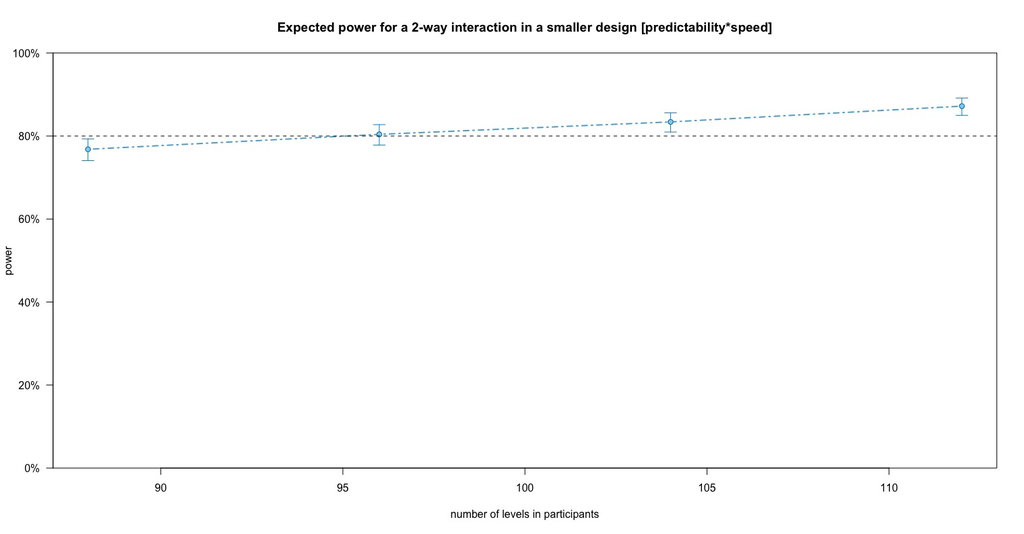

An example of powercurve.

This is a real powercurve that I’d prepared for one of my experiments.  
It shows how power (y-axis) increases with an increase in sample size (x-axis). In this experiment, I needed a sample size of at least 96 to detect the effect size of interest for *predictability x speed* interaction with 80% power.

# 7 Conclusion

In our hypothetical experiment, at this point, we can’t really say how many participants we should recruit for a well-powered study to detect effect size of interest re the variable `noise`. Try runnig 10000 simulations and see. Also, is the model specification correct for the repeated measures?

There are many factors that determine the result of your sample size estimation for an effect size of interest. For example, did you assign and interpret correct contrasts? Are you interested in the effect size of only one variable or more? How do you take into account the random effects? All these questions deserve separate discussion, I believe. But for now, we can work with this seemingly simple case.  
All the best!

And enjoy [this piece](https://www.youtube.com/watch?v=JwFNShcDlh8) titled *Hearing noises* 🎶🔊

# 8 Notes

- Many researchers disagree with this approach of sample size estimation from a pilot study. Be mindful of their criticism and feedback.
- We can get post-hoc power of a variable using the `powerSim` command in m0 instead of extended model as done above. Be careful why you perform post-hoc power analysis and check its critiques.
- Check [Green and MacLeod (2015)](https://doi.org/10.1111/2041-210X.12504) for a better and elaborate discussion about `simr` package for power estimation and sample size calculation.
- There are other resources which I have followed, but I don’t remember them right now. I’ll add them in references soon. Apologies to the authors!
- Please do comment if you find mistakes above, or improvements can be made.